# Biostat 203B Homework 4

Due Mar 20 @ 11:59PM

Burson Tang UID#305068045

# Task

In this assignment, you are to write a report analyzing the electronic health record (EHR) data MIMIC-III. You report will demostrate your knowledge of working with PostgreSQL database, data visualization, and commonly used analytical methods such as logistic regression and neural network. Your report should include at least following parts:

1. An informative title. For example, *30-Day Mortality Rate of Myocardia Infarction Patients Admitted to CCU*.
2. Introduction. Describe the MIMIC-III data set and what research hypothesis/goal you are to address using this data.
3. Data preparation. Create a study cohort from MIMIC-III corresponding to your research hypothesis/goal. See the examplary code below. Use a CONSORT flow diagram to summarize your steps to create the cohort.
4. Data visualization. Use visualization to summarize the cohort you created.
5. Analytics. Use at least two analytical approaches to address your research hypothesis/goal. For example, we can use (1) logistic regression and (2) neural network to build a predictive model for the 30-day mortality rate of patients admitted into CCU and compare their predictive performance. Summarize your results in graphs.
6. Conclusions.

# Learning resources about analyzing EHR data

- *Secondary Analysis of Electronic Health Records*: https://link.springer.com/book/10.1007/978-3-319-43742-2
- *The Book of OHDSI*: https://ohdsi.github.io/TheBookOfOhdsi/.
- The GitHub repository https://github.com/MIT-LCP/mimic-code contains some code examples for working with the MIMIC-III data. Following sample code derives from https://github.com/MIT-LCP/mimic-code/blob/master/tutorials/dplyr-frontend/intro.md.

*Report starts here*

# Title: Mortality Rate of Influenza Patients Admitted to the Hospital

## 1. Introduction

The COVID-19 has made headlines in recent weeks and been regarded as an epidemic hitting countries around the world. To March 22, 2020, there has been more than 2 millions people diagnosed as COVID-19 and more than 24,000 death because of this virus. Many people compared this virus with flu, which has already caused an estimated 19 million illnesses in the U.S. alone from CDC estimation. This project aims to investigate influenza patients information and maybe create models with these data to predict future 30-days mortality of influenza patients.

## 2. Data Preparation

Load database libraries and the tidyverse frontend:

```r
library(DBI)
library(RPostgreSQL)
library(tidyverse)
library(lubridate)
library(scales)
```

Connect to PostgresSQL datanase: Credentials for using PostgreSQL database. We are going to use username `postgres` with password `postgres` to access the `mimic` database in the schemee `mimiciii`.

```r
# Load configuration settings
dbdriver <- 'PostgreSQL'
#host  <- '127.0.0.1'
#port  <- '5432'
user  <- 'postgres'
password <- 'postgres'
dbname <- 'mimic'
schema <- 'mimiciii'
# Connect to the database using the configuration settings
con <- dbConnect(RPostgreSQL::PostgreSQL(),
                 dbname = dbname,
                 #host = host,
                 #port = port,
                 user = user,
                 password = password)
# Set the default schema
dbExecute(con, paste("SET search_path TO ", schema, sep=" "))
```

```
## [1] 0
```

```r
con
```

```
## <PostgreSQLConnection>
```

```r
# List tables in the `mimic` database:
dbListTables(con)
```

```
##   [1] "admissions"         "callout"            "caregivers"
##   [4] "chartevents_1"      "chartevents"        "chartevents_2"
##   [7] "chartevents_3"      "chartevents_4"      "chartevents_5"
##  [10] "chartevents_6"      "chartevents_7"      "chartevents_8"
##  [13] "chartevents_9"      "chartevents_10"     "inputevents_mv"
##  [16] "labevents"          "chartevents_11"     "chartevents_12"
##  [19] "chartevents_13"     "chartevents_14"     "microbiologyevents"
##  [22] "chartevents_15"     "chartevents_16"     "chartevents_17"
##  [25] "chartevents_18"     "chartevents_19"     "chartevents_20"
##  [28] "chartevents_21"     "chartevents_22"     "chartevents_23"
##  [31] "noteevents"         "outputevents"       "chartevents_24"
##  [34] "chartevents_25"     "chartevents_26"     "chartevents_27"
##  [37] "chartevents_28"     "patients"           "chartevents_29"
##  [40] "chartevents_30"     "chartevents_31"     "chartevents_32"
##  [43] "chartevents_33"     "chartevents_34"     "chartevents_35"
```

[output cut: 90 more lines]

The table `d_icd_diagnoses` stores all types of diagnosis and corresponding codes, from which the influenza-related diagnosis are extracted.

```r
# Connect to the admissions table
Admissions <- tbl(con, "admissions")
Admissions %>% print(width = Inf)
```

```
## # Source:   table<admissions> [?? x 19]
## # Database: postgres 11.0.7 [postgres@/var/run/postgresql:5432/mimic]
##    row_id subject_id hadm_id admittime           dischtime
##     <int>      <int>   <int> <dttm>              <dttm>
##  1     21         22  165315 2196-04-09 12:26:00 2196-04-10 15:54:00
##  2     22         23  152223 2153-09-03 07:15:00 2153-09-08 19:10:00
##  3     23         23  124321 2157-10-18 19:34:00 2157-10-25 14:00:00
##  4     24         24  161859 2139-06-06 16:14:00 2139-06-09 12:48:00
##  5     25         25  129635 2160-11-02 02:06:00 2160-11-05 14:55:00
##  6     26         26  197661 2126-05-06 15:16:00 2126-05-13 15:00:00
##  7     27         27  134931 2191-11-30 22:16:00 2191-12-03 14:45:00
##  8     28         28  162569 2177-09-01 07:15:00 2177-09-06 16:00:00
##  9     29         30  104557 2172-10-14 14:17:00 2172-10-19 14:37:00
## 10     30         31  128652 2108-08-22 23:27:00 2108-08-30 15:00:00
##    deathtime           admission_type admission_location
```

[output cut: 60 more lines]

```r
# Pneu <- Admission %>% filter(str_detect(tolower(DIAGNOSIS), "PNEUMONIA"))

tbl(con, "d_icd_diagnoses")%>% summarize(n())
```

```
## # Source:   lazy query [?? x 1]
## # Database: postgres 11.0.7 [postgres@/var/run/postgresql:5432/mimic]
##   `n()`
##   <dbl>
## 1 14567
```

```r
# Find all diagnoses code for influenza
tbl(con, "d_icd_diagnoses") %>%
  filter(str_detect(long_title, "influenza")) %>% print(width = Inf) ->
  flu_codes
```

```
## # Source:   lazy query [?? x 4]
## # Database: postgres 11.0.7 [postgres@/var/run/postgresql:5432/mimic]
##    row_id icd9_code short_title
##     <int> <chr>     <chr>
##  1    502 0415      H. influenzae infect NOS
##  2    654 03841     H. influenae septicemia
##  3   5496 4802      Parinfluenza viral pneum
##  4   5503 4822      H.influenzae pneumonia
##  5   5532 48801     Flu dt iden avian w pneu
##  6   5533 48802     Flu dt avian w oth resp
##  7   5534 48809     Flu dt avian manfest NEC
##  8   5535 48811     Flu dt 2009 H1N1 w pneu
##  9   5536 48812     Flu-2009 H1N1 w oth resp
## 10   5537 48819     Flu-2009 H1N1 w oth man
##    long_title
##    <chr>
##  1 Hemophilus influenzae [H. influenzae] infection in conditions classified els…
##  2 Septicemia due to hemophilus influenzae [H. influenzae]
##  3 Pneumonia due to parainfluenza virus
##  4 Pneumonia due to Hemophilus influenzae [H. influenzae]
##  5 Influenza due to identified avian influenza virus with pneumonia
##  6 Influenza due to identified avian influenza virus with other respiratory man…
##  7 Influenza due to identified avian influenza virus with other manifestations
##  8 Influenza due to identified 2009 H1N1 influenza virus with pneumonia
##  9 Influenza due to identified 2009 H1N1 influenza virus with other respiratory…
## 10 Influenza due to identified 2009 H1N1 influenza virus with other manifestati…
## # … with more rows
```

`diagnoses_icd` table stores the diagnosis of each admission. We use semi_join() to keep the rows in `diagnoses_icd` that match the codes related to influenza:

```r
# get all the admission because of flue via semi_join
tbl(con, "diagnoses_icd") %>%
  semi_join(flu_codes, by = "icd9_code") %>%
  print() -> flu_adm
```

```
## # Source:   lazy query [?? x 5]
## # Database: postgres 11.0.7 [postgres@/var/run/postgresql:5432/mimic]
##    row_id subject_id hadm_id seq_num icd9_code
##     <int>      <int>   <int>   <int> <chr>
##  1  31887       2830  193970      11 0415
##  2  33158       2974  159182       4 0415
##  3  21630       1948  179684       4 0415
##  4  59734       5340  143777       5 0415
##  5 104068       9286  139128       9 0415
##  6 117149      10453  131615       7 0415
##  7 210254      18901  129544      10 0415
##  8 261013      23417  102513       8 0415
##  9 275799      24708  197576      17 0415
## 10 326148      28716  150867      13 0415
## # … with more rows
```

According to the documentation for the `patients` table, patients can have different diagnosis, and thus influenza may not be listed as the principal diagnosis. In order to focus on patients for whom influenza was central to their hospitalization, we will include records with influenza in any of the first five diagnosis positions according to the `seq_num` field. To avoid duplicate admissions, only the first influenza diagnosis for each admission is used in the analysis. At the end, a logical variable indicating the influenza is the principal diagonosis or not (the influenza is regarded as the principal diagnosis only if records have `seq_num` equal to one).

```r
# Use filter to only include records with flu in top five diagnosis positions
flu_adm %>%
  filter(seq_num <= 5) %>%
  group_by(subject_id, hadm_id) %>%
  # top_n(1, wt = seq_num) %>% #  not working. bug? use following as workaround
  filter(min_rank(seq_num) <= 1) %>%
  ungroup() %>%
  select(subject_id, hadm_id, icd9_code, seq_num) %>%
  # check if the flu is the principal diagnosis
  mutate(principal_dx = (seq_num == 1)) %>%
  select(-seq_num) %>%
  print() -> flu_adm
```

```
## # Source:   lazy query [?? x 4]
## # Database: postgres 11.0.7 [postgres@/var/run/postgresql:5432/mimic]
##    subject_id hadm_id icd9_code principal_dx
##         <int>   <int> <chr>     <lgl>
##  1        236  191151 4822      TRUE
##  2       1338  195037 4822      FALSE
##  3       1948  179684 0415      FALSE
##  4       2092  154019 4822      FALSE
##  5       2807  151250 4822      FALSE
##  6       2974  159182 0415      FALSE
##  7       3181  122963 4822      FALSE
##  8       4699  159743 4822      FALSE
##  9       5340  143777 0415      FALSE
## 10       5573  177000 4822      FALSE
## # … with more rows
```

`inner_join` the table of admission `admissions` with the table of influenza-caused admission to pull the admitting and discharge time and other necessary information. Also join the `patients` table to get more detailed demographic information of the patients admitted into hospital.

Here the `hospital_expire_flag` and `expire_flag` are logical variables indicating whether the patient died (1) or not (0). Create more intelligible variable names for them.

```r
select(tbl(con, "admissions"),
       subject_id, hadm_id, admittime, dischtime, hospital_expire_flag, ethnicity)%>%
  inner_join(flu_adm, by = c("subject_id", "hadm_id")) %>%
  left_join(
    select(tbl(con, "patients"), -row_id, -dod_hosp, -dod_ssn),
    by = "subject_id") %>%
  mutate(mortality_in_hospital = hospital_expire_flag==1,
         mortality_general = expire_flag==1) %>%
  select(-hospital_expire_flag, -expire_flag) %>%
  print() -> flu_admissions
```

```
## # Source:   lazy query [?? x 12]
## # Database: postgres 11.0.7 [postgres@/var/run/postgresql:5432/mimic]
##    subject_id hadm_id admittime           dischtime           ethnicity
##         <int>   <int> <dttm>              <dttm>              <chr>
##  1        236  191151 2139-02-18 14:26:00 2139-04-08 15:30:00 PATIENT …
##  2       1338  195037 2108-12-07 11:34:00 2108-12-27 14:30:00 HISPANIC…
##  3       1948  179684 2173-03-12 22:21:00 2173-03-18 23:09:00 OTHER
##  4       2092  154019 2180-12-16 12:40:00 2180-12-29 09:00:00 WHITE
##  5       2807  151250 2175-08-15 07:15:00 2175-09-06 16:13:00 WHITE
##  6       2974  159182 2165-11-23 05:40:00 2165-12-19 13:15:00 HISPANIC…
##  7       3181  122963 2120-07-19 07:15:00 2120-07-31 14:27:00 UNKNOWN/…
##  8       4699  159743 2148-04-03 12:41:00 2148-04-12 19:15:00 WHITE
##  9       5340  143777 2106-12-29 04:27:00 2107-01-03 12:28:00 WHITE
## 10       5573  177000 2139-04-05 19:39:00 2139-04-18 15:30:00 WHITE
## # … with more rows, and 7 more variables: icd9_code <chr>, principal_dx <lgl>,
## #   gender <chr>, dob <dttm>, dod <dttm>, mortality_in_hospital <lgl>,
## #   mortality_general <lgl>
```

Calculate the age for all patients in the table. According to the documentation for the patients table, the patients of 90 years and older had their ages artficially inflated, and thus removed from the table. Some important variables are moved to the front.

*Note* Many mortality indicators are missing, due to neither the hospital database nor the social security database having a record of these patients’ deaths, i.e., they patients are still alive. This is also verified by the aforementioned morality variables, and thus the NA values are converted to FALSE values. The code used for verification is commented out.

```r
## Code for verification
# flu_admissions %>%
#   mutate(tt_death = date_part("day", dod) - date_part("day", dischtime))  %>%
#   mutate(verification = !is.na(tt_death)) ->c
# (all(c$verification == c$mortality_general))

flu_admissions %>%
  mutate(tt_death = date_part("day", dod) - date_part("day", dischtime)) %>%
  mutate(mortality_30 = ifelse(is.na(tt_death)||tt_death>30, F, T) ) %>%
  mutate(age = date_part("year", admittime) - date_part("year", dob)) %>%
  filter(age < 90) %>%
  mutate(age = age - ifelse(
    date_part("month", admittime) < date_part("month", dob) |
      (
        date_part("month", admittime) == date_part("month", dob) &
          date_part("day", admittime) < date_part("day", dob)
      ),
    1,
    0
  )) %>%
  select(-admittime, -dischtime, -dob, -dod, -tt_death) %>%
  select(subject_id, hadm_id, age, mortality_general,
         mortality_in_hospital, mortality_30, everything()) %>%
  print() -> flu_admissions
```

```
## # Source:   lazy query [?? x 10]
## # Database: postgres 11.0.7 [postgres@/var/run/postgresql:5432/mimic]
##    subject_id hadm_id   age mortality_gener… mortality_in_ho… mortality_30
##         <int>   <int> <dbl> <lgl>            <lgl>            <lgl>
##  1        236  191151    57 TRUE             FALSE            TRUE
##  2       1338  195037    77 FALSE            FALSE            FALSE
##  3       1948  179684    32 FALSE            FALSE            FALSE
##  4       2092  154019    46 FALSE            FALSE            FALSE
##  5       2807  151250    66 FALSE            FALSE            FALSE
##  6       2974  159182    50 FALSE            FALSE            FALSE
##  7       3181  122963    79 TRUE             FALSE            TRUE
##  8       4699  159743    36 FALSE            FALSE            FALSE
##  9       5340  143777    45 FALSE            FALSE            FALSE
## 10       5573  177000    72 TRUE             FALSE            TRUE
## # … with more rows, and 4 more variables: ethnicity <chr>, icd9_code <chr>,
## #   principal_dx <lgl>, gender <chr>
```

CONSORT Flow Diagrams are generated for the flow of data preparation.

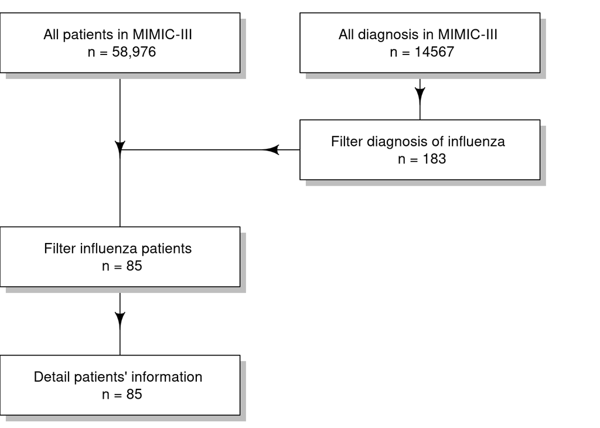

```r
library(shape)
library(diagram)

# set margins and multiplot
par(mfrow = c(1, 1))
par(mar = c(0, 0, 0, 0))

# initialise a plot device
openplotmat()

# position of boxes
num_of_boxes <- 5
auto_coords = coordinates(num_of_boxes)
vert_pos = rev(auto_coords[,1])
box_pos <- matrix(nrow = num_of_boxes, ncol = 2, data = 0)
box_pos[1,] = c(0.20, vert_pos[1]) # 1st box
box_pos[2,] = c(0.70, vert_pos[1]) # 2nd box
box_pos[3,] = c(0.70, vert_pos[2]-.05)
box_pos[4,] = c(0.20, vert_pos[3]-.1) # 3rd box
box_pos[5,] = c(0.20, vert_pos[4]-.2) # etc...


# content of boxes
box_content <- matrix(nrow = num_of_boxes, ncol = 1, data = 0)
box_content[1] = "All patients in MIMIC-III \n n = 58,976" # 1st box
box_content[2] = "All diagnosis in MIMIC-III \n n = 14567" # 2nd box
box_content[3] = "Filter diagnosis of influenza \n n = 183" # 3rd box
box_content[4] = "Filter influenza patients \n n = 85" # etc...
box_content[5] = "Detail patients' information \n n = 85"

# adjust the size of boxes to fit content
box_x <- c(0.20, 0.20, 0.20, 0.20, 0.20)
box_y <- c(0.07, 0.07, 0.07, 0.07, 0.07)
# Draw the arrows
straightarrow(from = box_pos[2,], to = box_pos[3,], lwd = 1)
straightarrow(from = box_pos[3,], to = c(0.20, box_pos[3,2]), lwd = 1)
straightarrow(from = box_pos[1,], to = box_pos[4,], lwd = 1)
straightarrow(from = box_pos[4,], to = box_pos[5,], lwd = 1)

# Draw the boxes
for (i in 1:num_of_boxes) {
  textrect(mid = box_pos[i,], radx = box_x[i], rady = box_y[i],
           lab = box_content[i],
           shadow.col = "grey")
  }
```

## 3. Data Visualization

Gender distribution of the influenza patients: the male patients number is more than twice as many as female ones.

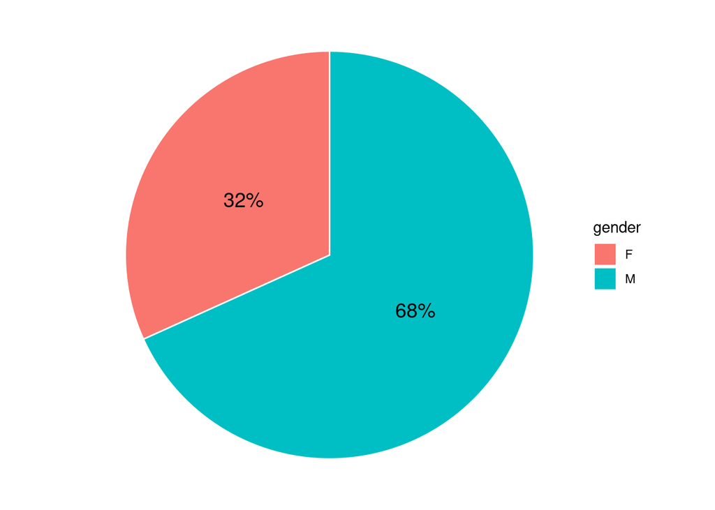

```r
flu_admissions %>%
  # count male or female patients numbers
  group_by(gender) %>%
  summarise(count=n())%>%

  # calculate percentage for label
  mutate(Prop = count/sum(count)) %>%

  # fix the plotting order so I can make label in accordingly
  arrange(desc(gender)) %>%
  ggplot(aes(x = "", y= Prop, fill= gender)) +
  geom_bar(width=1, stat = "identity",color = "white")+
  coord_polar(theta = 'y', direction = 1)+

  # add percentage labels on the pie charte
  geom_text(aes(y = cumsum(Prop) - 0.5*Prop,  # label position
            label = percent(Prop)), size=5)+ # label value and size


  # get rid of all the axis labels and ticks
  theme_void()+
  scale_x_discrete(breaks = NULL)+
  labs(x="",y="")+
  theme(axis.text.x=element_blank(),axis.text.y=element_blank())
```

Age distribution of the influenza patients: Most of the patients admitted for influenza-related reasons are those older than 40 years old. Also with the increase of age, the mortality increases except for patients in 90s, the total number of which is too small.

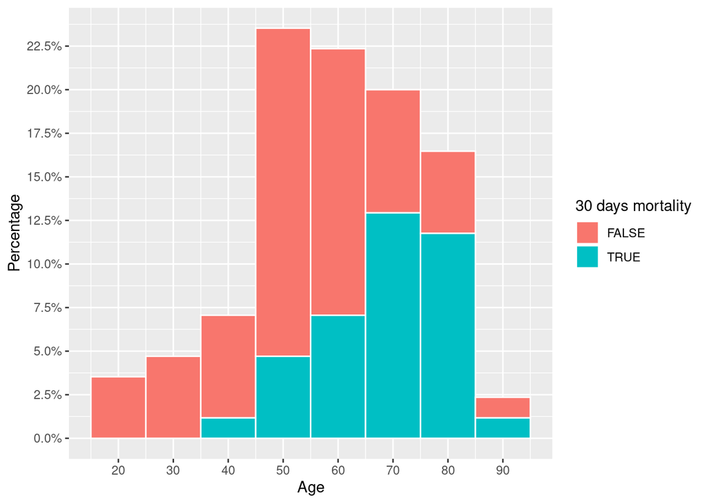

```r
flu_admissions %>%
  ggplot() +
  geom_histogram(mapping = aes(x=age,y = (..count..)/sum(..count..),
                               fill = mortality_30),
           binwidth = 10, color = "white")+
  scale_y_continuous(breaks = seq(0,.25,.025), labels = percent,
                     name="Percentage")+
  scale_x_continuous( breaks = seq(0,100,10), name = "Age")+
  labs(fill = "30 days mortality")
```

Ethnicity: Most of the patients admitted for influenza is white, accounting for more than 70% of patients.

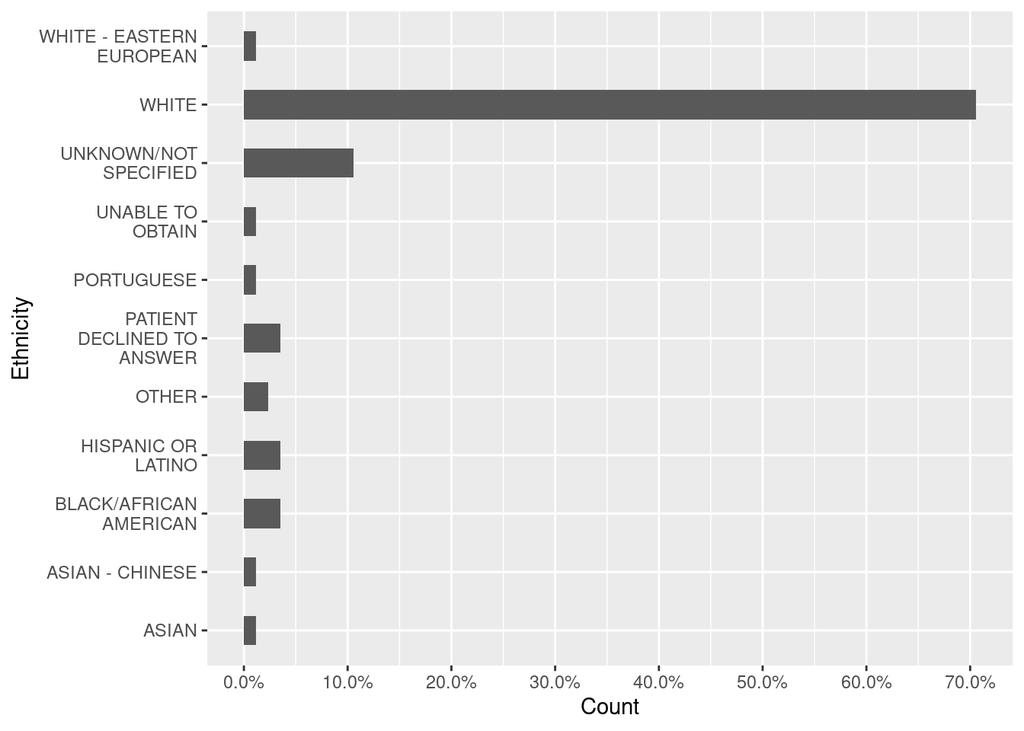

```r
flu_admissions %>%
    group_by(ethnicity)  %>%
  summarise(count=n()) %>%
  mutate(Prop = count/sum(count))%>%

  ggplot() +
  geom_bar(mapping=aes(stringr::str_wrap(ethnicity,15), y = Prop),
           stat = "identity", width=0.5)+
  scale_y_continuous(breaks = seq(0,.7,.1),labels = percent)+
  labs(x='Ethnicity', y='Count')+
  coord_flip()
```

Morality: The general mortality plot is identical to the 30-days mortality plot, which means 39% of these patients died in 30-days after admission because of influenza-realted reason. And the in-hospital mortality is relatively low. Only 8% of these patients died in the hospital

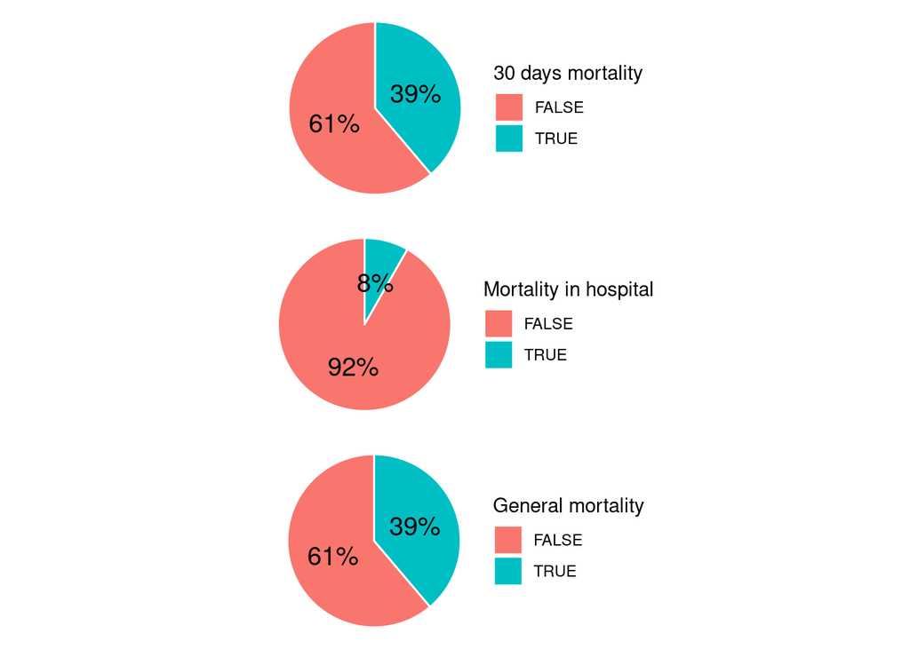

```r
flu_admissions %>%
  group_by(mortality_30) %>%
  summarise(count = n()) %>%
  # calculate percentage for label
  mutate(Prop = count/sum(count)) %>%

  # fix the plotting order so I can make label in accordingly
  arrange(desc(mortality_30)) %>%

  # Use percentage value as y values, and set stat as identity
  ggplot(aes(x = "", y= Prop, fill= mortality_30)) +

  # separate pie chart segment with white lines
  geom_bar(width = 1, color = "white",stat="identity")+
  coord_polar(theta = 'y', direction = 1)+

  # add percentage labels on the pie charte
  geom_text(aes(y = cumsum(Prop) - 0.5*Prop,  # label position
            label = percent(Prop)), size=5)+ # label value and size

  # get rid of all the axis labels and ticks
  theme_void()+
  scale_x_discrete(breaks = NULL)+
  labs(x="",y="", fill = "30 days mortality")+
  theme(axis.text.x=element_blank(),axis.text.y=element_blank()) -> p1

flu_admissions %>%
  group_by(mortality_in_hospital) %>%
  summarise(count = n()) %>%
  # calculate percentage for label
  mutate(Prop = count/sum(count)) %>%

  # fix the plotting order so I can make label in accordingly
  arrange(desc(mortality_in_hospital)) %>%

  # Use percentage value as y values, and set stat as identity
  ggplot(aes(x = "", y= Prop, fill= mortality_in_hospital)) +

  # separate pie chart segment with white lines
  geom_bar(width = 1, color = "white",stat="identity")+
  coord_polar(theta = 'y', direction = 1)+

  # add percentage labels on the pie charte
  geom_text(aes(y = cumsum(Prop) - 0.5*Prop,  # label position
            label = percent(Prop)), size=5)+ # label value and size

  # get rid of all the axis labels and ticks
  theme_void()+
  scale_x_discrete(breaks = NULL)+
  labs(x="",y="", fill = "Mortality in hospital")+
  theme(axis.text.x=element_blank(),axis.text.y=element_blank()) -> p2

flu_admissions %>%
  group_by(mortality_general) %>%
  summarise(count = n()) %>%
  # calculate percentage for label
  mutate(Prop = count/sum(count)) %>%

  # fix the plotting order so I can make label in accordingly
  arrange(desc(mortality_general)) %>%

  # Use percentage value as y values, and set stat as identity
  ggplot(aes(x = "", y= Prop, fill= mortality_general)) +

  # separate pie chart segment with white lines
  geom_bar(width = 1, color = "white",stat="identity")+
  coord_polar(theta = 'y', direction = 1)+

  # add percentage labels on the pie charte
  geom_text(aes(y = cumsum(Prop) - 0.5*Prop,  # label position
            label = percent(Prop)), size=5)+ # label value and size

  # get rid of all the axis labels and ticks
  theme_void()+
  scale_x_discrete(breaks = NULL)+
  labs(x="",y="", fill = "General mortality")+
  theme(axis.text.x=element_blank(),axis.text.y=element_blank()) -> p3

library(gridExtra)
grid.arrange(p1, p2, p3, nrow = 3)
```

## 4. Analytics

1. *Logistic Regression* Here we try to predict the 30-day mortality by using the gender and age of the patients. The `ethnicity` and `principal_dx` are not considered because most of the patients are white and the influenza is not the number#1 diagnosis, which makes both variable not statistically significant. The 30-days mortality can be calculated as:

```r
flu_admissions$gender <- factor(flu_admissions$gender)
flu_admissions$principal_dx <- factor(flu_admissions$principal_dx)
flu_admissions$mortality_general <- factor(flu_admissions$mortality_general )

logitA <- glm(mortality_general ~ gender + age,
              data = flu_admissions, family = "binomial")

summary(logitA)
```

```
##
## Call:
## glm(formula = mortality_general ~ gender + age, family = "binomial",
##     data = flu_admissions)
##
## Deviance Residuals:
##     Min       1Q   Median       3Q      Max
## -2.0662  -0.8584  -0.3880   0.8910   2.5985
##
## Coefficients:
##             Estimate Std. Error z value Pr(>|z|)
## (Intercept) -6.49018    1.59824  -4.061 4.89e-05 ***
## genderM      1.28955    0.59970   2.150 0.031528 *
## age          0.08287    0.02201   3.765 0.000167 ***
## ---
## Signif. codes:  0 '***' 0.001 '**' 0.01 '*' 0.05 '.' 0.1 ' ' 1
##
## (Dispersion parameter for binomial family taken to be 1)
##
##     Null deviance: 113.552  on 84  degrees of freedom
## Residual deviance:  89.889  on 82  degrees of freedom
## AIC: 95.889
##
## Number of Fisher Scoring iterations: 5
```

```r
library(keras)


# divide the table
o_train <- sample(seq(1,85,1),60)
flu_admissions_t <- collect(flu_admissions) %>%
  select(mortality_general, gender, age) %>%
  mutate(mortality_general = ifelse(mortality_general,1,0),
         gender = ifelse(gender =="M",1,0))

# c <- as.matrix(flu_admissions_t )
x_train <- as.matrix(flu_admissions_t[o_train,2:3])
# y_train <- as.matrix(flu_admissions_t[o_train,1])
y_train <- array(flu_admissions_t$mortality_general[o_train]) %>%
  to_categorical(2)

x_test <- as.matrix(flu_admissions_t[-o_train,2:3])
# y_test <- as.matrix(flu_admissions_t[-o_train,1])
y_test <- array(flu_admissions_t$mortality_general[-o_train]) %>%
  to_categorical(2)

# Disconnect the database, from now on, connection not required
dbDisconnect(con)
```

```
## [1] TRUE
```

```r
mlogit <- keras_model_sequential()
mlogit %>%
  layer_dense(units = 4, activation = 'linear', input_shape = c(2)) %>%
  layer_dropout(rate = 0.4) %>%
  layer_dense(units = 4, activation = 'relu', input_shape = c(2)) %>%
  layer_dropout(rate = 0.4) %>%
  # layer_dense(units = 10, activation = 'relu', input_shape = c(2)) %>%
  # layer_dropout(rate = 0.4) %>%
  layer_dense(units = 2, activation = 'softmax', input_shape = c(2))
summary(mlogit)
```

```
## Model: "sequential"
## ________________________________________________________________________________
## Layer (type)                        Output Shape                    Param #
## ================================================================================
## dense (Dense)                       (None, 4)                       12
## ________________________________________________________________________________
## dropout (Dropout)                   (None, 4)                       0
## ________________________________________________________________________________
## dense_1 (Dense)                     (None, 4)                       20
## ________________________________________________________________________________
## dropout_1 (Dropout)                 (None, 4)                       0
## ________________________________________________________________________________
## dense_2 (Dense)                     (None, 2)                       10
## ================================================================================
## Total params: 42
## Trainable params: 42
## Non-trainable params: 0
## ________________________________________________________________________________
```

```r
# compile model
mlogit %>% compile(
  loss = 'categorical_crossentropy',
  optimizer = optimizer_rmsprop(),
  metrics = c('accuracy')
)

# fit model
mlogit_history <- mlogit %>% fit(
  x_train, y_train,
  epochs = 20, batch_size = NULL,
  validation_split = 0.2
)


# Evaluate model performance on the test data:
mlogit %>% evaluate(x_test, y_test)
```

```
## $loss
## [1] 9.349303
##
## $accuracy
## [1] 0.72
```

## 5. Conclusion

And the Neural Network model can predict with an accuracy of 72%.